# slide_deck_template slides

## (Ford GoBike System Data)

### by (Ahmed Alshabouri)

> this a data set containing the information of a bike share system San Francisco.

## Investigation Overview

> my goal to explore this data of the Ford gobike and get visualization and data insights to observe some findings

## Dataset Overview

> data set describe the details of every trip including duration, trip start time and end time, start station detaails such as id, name, latitude, longitude, with the same for the end station also bike id is provided along with user type if it is subscriber = member or customer = guest and then a detailed information about the user its gender and birth.

### time spent on the bike

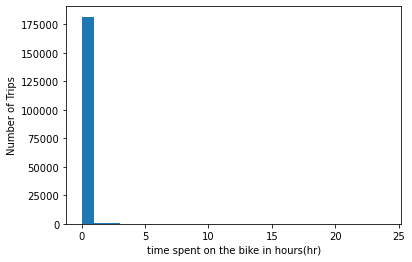

```python
bins = np.arange(0, df['dur_hr'].max()+1, 1)
plt.hist(data = df, x = 'dur_hr', bins = bins)
plt.ylabel('Number of Trips')
plt.xlabel('time spent on the bike in hours(hr)')
plt.show()
```

## (time spent on the bike per minute)

> where it is a right skewed histogram as the peak is found between 0 to 15 mins

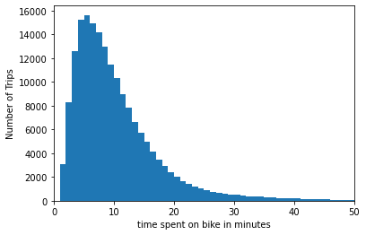

```python
bins = np.arange(0, df['dur_min'].max()+1, 1)
plt.hist(data = df, x = 'dur_min', bins = bins)
plt.xlim([0,50])
plt.xlabel('time spent on bike in minutes')
plt.ylabel('Number of Trips')
plt.show()
```

## (No. of subscribers to customers)

> number of subscribers are way more than the number of customers

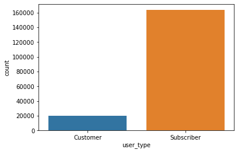

```python
sb.countplot(data=df,x='user_type')
```

### Distribution of User Age

In the case of age, we see that users are more concentrated between 19 to 38 years old.

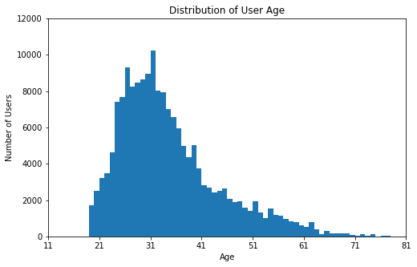

```python
binsize = 1
bins = np.arange(0, df['member_birth_year'].astype(float).max()+binsize, binsize)

plt.figure(figsize=[8, 5])
plt.hist(data = df.dropna(), x = 'member_birth_year', bins = bins)
plt.axis([1939, 2009, 0, 12000])
plt.xticks([1939, 1949, 1959, 1969, 1979, 1989, 1999, 2009], [(2020-1939), (2020-1949), (2020-1959), (2020-1969), (2020-1979), (2020-1989), (2020-1999), (2020-2009)])
plt.gca().invert_xaxis()
plt.title('Distribution of User Age')
plt.xlabel('Age')
plt.ylabel('Number of Users')
plt.show()
```

## (exploring the daily statistics)

> we see that the peak days aren't really an indication as it is randomly distributed

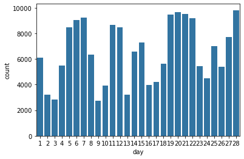

```python
sb.countplot(data=df,x='day', color=sb.color_palette()[0])
```

## (exploring the relation between user type and time spent on bike.)

> despite having a huge number of subscribers but the usage of the customers are way more.

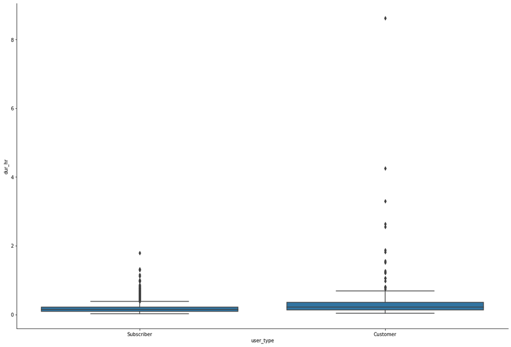

```python
samples = np.random.choice(df.shape[0], 2000, replace = False)
df_samp = df.reindex(samples)
def boxgrid(x, y, **kwargs):
    default_color = sb.color_palette()[0]
    sb.boxplot(x, y, color = default_color)

plt.figure(figsize = [10, 10])
g = sb.PairGrid(data = df_samp, y_vars = 'dur_hr', x_vars = 'user_type',
                size = 10, aspect = 1.5)
plt.ylabel('duration(hr)')
g.map(boxgrid)
plt.show();
```

## (exploring the relation between the duration in minutes and the day)

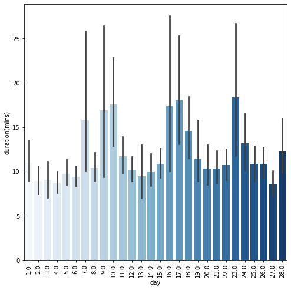

```python
plt.figure(figsize = [8, 8])
sb.barplot(data = df_samp, x = 'day', y = 'dur_min', palette = 'Blues' )
plt.xticks(rotation=90)
plt.ylabel('duration(mins)')
plt.show()
```

### Trip Duration vs. Age

By looking at the graph below,most users are aged between 20 and 50 where the higher duration is done by younger people

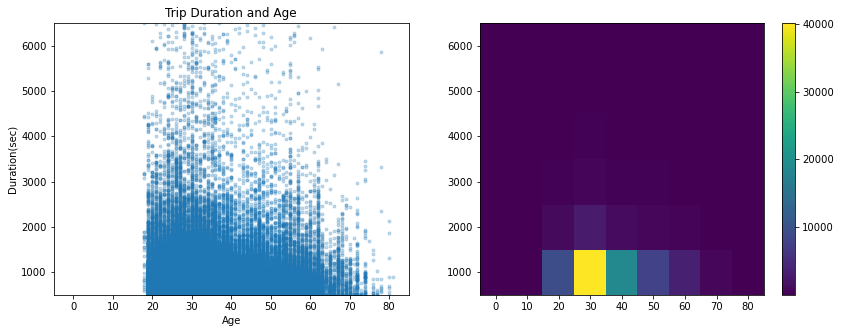

```python
plt.figure(figsize=[14,5])

plt.subplot(1, 2, 1)
plt.scatter((2019 - df['member_birth_year']), df['duration_sec'], alpha = 0.25, marker = '.' )
plt.axis([-5, 85, 500, 6500])
plt.title('Trip Duration and Age')
plt.xlabel('Age')
plt.ylabel('Duration(sec)')

plt.subplot(1, 2, 2)
bins_y = np.arange(500, 6500+1, 1000)
bins_x = np.arange(-5, 85+1, 10)
plt.hist2d((2019 - df['member_birth_year']), df['duration_sec'],
           bins = [bins_x, bins_y])
plt.colorbar(ticks=[10000, 20000, 30000, 40000]);
plt.show()
```

## (creating a relationship between the three variables duration, user type and day)

we observe that the customer are having a more bike duration than subscribers.

[output not shown]

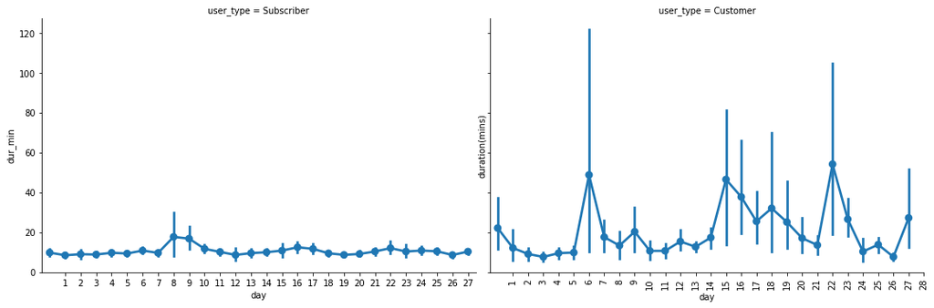

```python
def hist2dgrid(x, y, **kwargs):
    palette = kwargs.pop('color')
    plt.hist2d(x, y, cmap = palette, cmin = 0.5)
    bin_edges = np.arange(0,28,1)
    plt.ylabel('duration(mins)')
g=sb.FacetGrid(data=df_samp, col='user_type', col_wrap=2, size=5,aspect = 1.5)
g.map(sb.pointplot,'day', 'dur_min')
plt.ylabel('duration(mins)')
plt.xticks(rotation=90)

plt.xticks([1,2,3,4,5,6,7,8,9,10,11,12,13,14,15,16,17,18,19,20,21,22,23,24,25,26,27,28], ['1','2','3','4','5','6','7','8','9','10','11','12','13','14','15','16','17','18','19','20','21','22','23','24','25','26','27','28'])
```

### Trip Duration and Age by Gender

the main purpose of this graph is to explore the relation between trip duration and age with respect to gender and see how the analysis will go

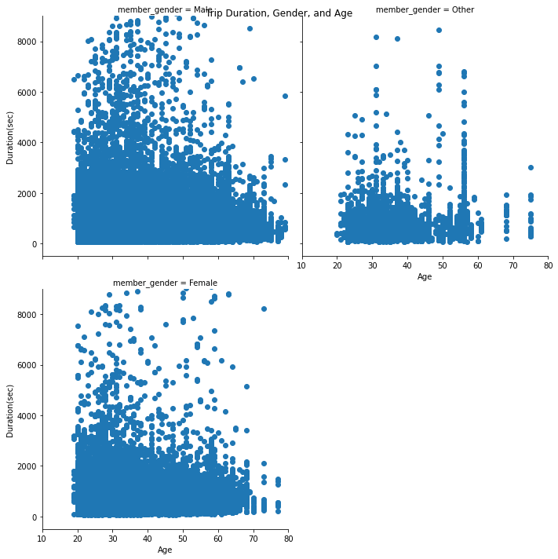

```python
df['age'] = (2020 - df['member_birth_year'])
gender = sb.FacetGrid(data = df, col = 'member_gender', col_wrap = 2, size = 5,
                 xlim = [10, 80], ylim = [-500, 9000])
gender.map(plt.scatter, 'age', 'duration_sec', alpha= 1)

gender.set_xlabels('Age')
gender.set_ylabels('Duration(sec)')
gender.fig.suptitle('Trip Duration, Gender, and Age')

plt.show()
```

### Trip Duration and Age by User Type

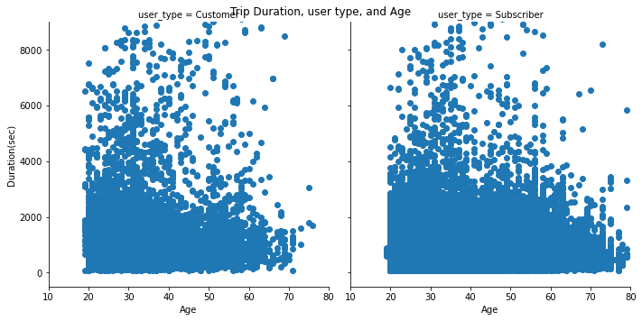

```python
user_type = sb.FacetGrid(data = df, col = 'user_type', col_wrap = 2, size = 5,
                 xlim = [10, 80], ylim = [-500, 9000])
user_type.map(plt.scatter, 'age', 'duration_sec', alpha= 1)

user_type.set_xlabels('Age')
user_type.set_ylabels('Duration(sec)')
user_type.fig.suptitle('Trip Duration, user type, and Age')
plt.show()
```